# PROTOCOL FOR:

## Data sources

- Niger measles data from project AERO
- Permissions?

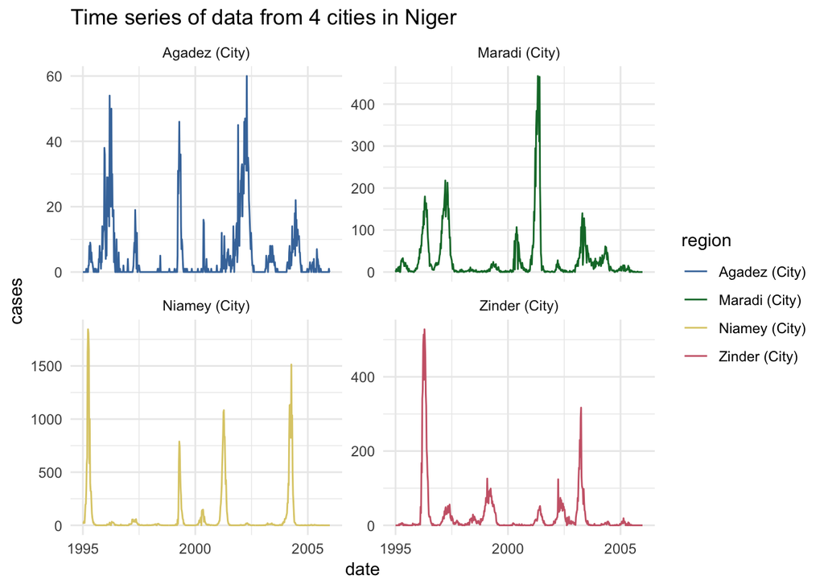

## Analysis

1. Plot time-indexed $\mathcal{R}_E$ and each EWS as scatterplots to visualize their correlations ($\rho$). This might look something like:

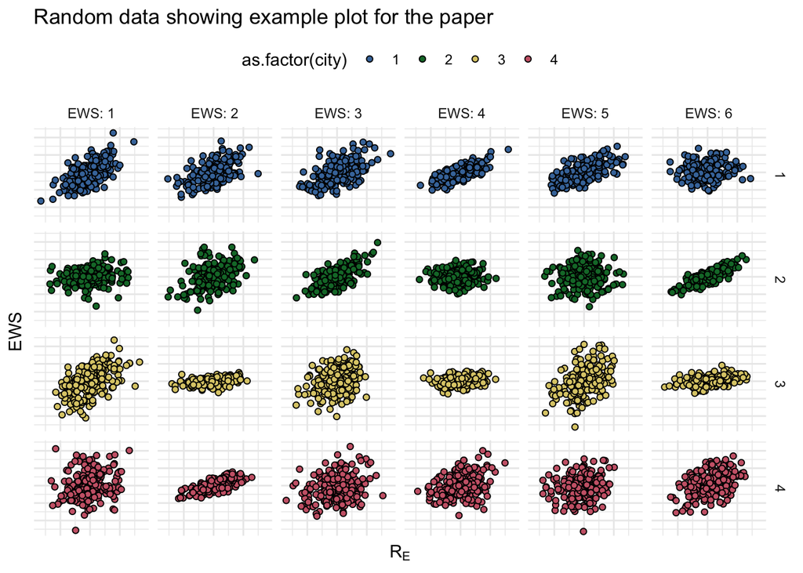

2. For each region, calculate temporal correlations between each EWS and $\mathcal{R}_E$, resulting in a table (or heatmap figure) like this:

| Region | EWS | $\boldsymbol{\rho}$ | *P*-value |
| --- | --- | --- | --- |
| Agadez | Variance | 0.8 | 0.001 |
| Agadez | Mean | 0.4 | 0.09 |
| $\vdots$ | $\vdots$ | $\vdots$ | $\vdots$ |
| Zinder | Kurtosis | 0.7 | 0.006 |

## Checklist

- Create cleaned dataset of just the four focal cities from Niger
- Write R code to define the `pomp` model object (SDE)
- Simulate time series from the `pomp` object with parameters that give us irregular dynamics like the observed data
- Do test analysis of steps II-III using the simulated data
- Perform iterated filter parameter search for MLEs
  - Get set up on UGA cluster
- Calculate EWS on the observed data
  - Work with Eamon on bandwidth, etc.
- Caclulate correlations with real data and empirically-derived $\mathcal{R}_E$
- Write the paper!